# Final

[figure not shown]

[figure not shown]

[figure not shown]

[figure not shown]

# Page 1

### Chart C

```
# A tibble: 6 × 3
  LEAID   SCHOOL_YEAR LEP_COUNT
  <chr>   <chr>           <dbl>
1 4100003 2018-2019          NA
2 4100009 2018-2019          86
3 4100014 2018-2019          34
4 4100015 2018-2019         248
5 4100016 2018-2019          16
6 4100019 2018-2019          22
```

# DLI

## Background

**Dual language immersion programs** aim to promote high academic achievement, full biliteracy, and develop social consciousness by grouping EL and monolingual students into one classroom while splitting instruction in English and a partner language. Evidence from rigorous studies finds that TWDLI programs has a positive impact on the academic achievement of EL classified students. Leveraging a lottery system to select participants into TWDLI programs at Portland Public Schools ¬– an ideal for an experimental design– Steele et. al., (2017) found that both EL and non-EL students who participated in DLI programs had higher fourth grade English language arts assessments compared to students who were not selected to participate in the program. These results are echoed by quasi-experimental studies in other settings (Watzinger-Tharp et al., 2018) and by meta-analysis that reviewed quantitative studies that interrogated the effects of bilingual education (Rolstad et. al., 2018).

**DLI programs in Oregon are present in at least 24 districts**. Districts with the largest programs tend to be more racially & linguistically diverse. For example, Portland, Beaverton, Hillsboro, Salem-Keizer, and Woodburn all have large DLI programs and serve a high proportion of EL students. However, many of the district programs are in districts that are less diverse.

### First Iteration of the graph

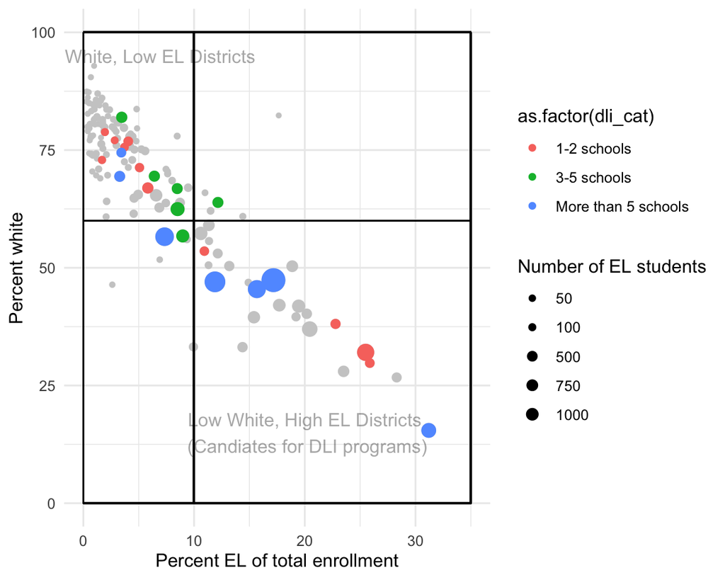

### Final Graph 1.

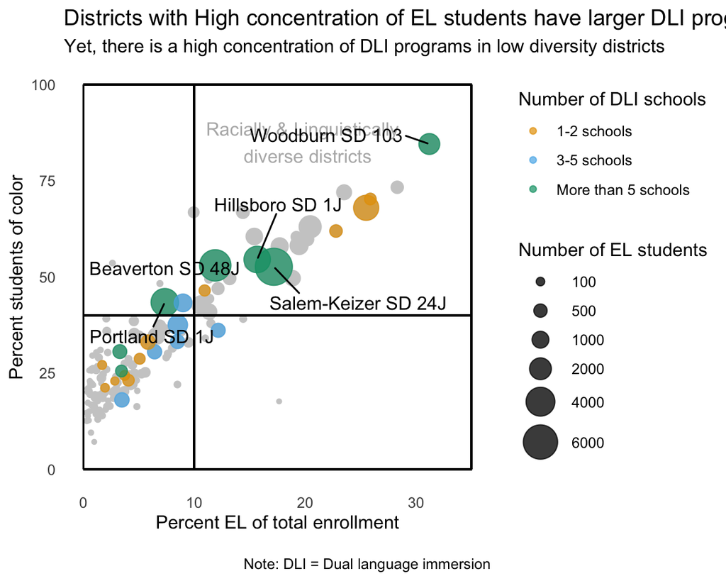

### Graph 2. Candidates for DLI

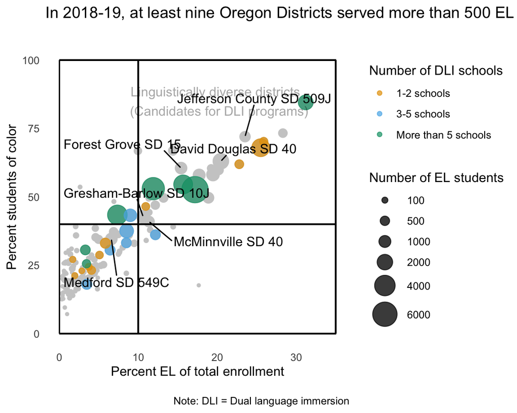

# Page 3

## Background

### First Iteration of the graph

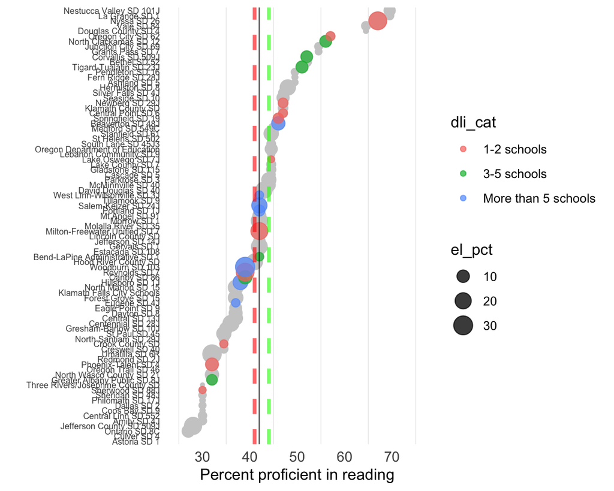